# Lecture 3. Optimization in machine learning problems

- The topic is very wide
- [Big book](https://mitpress.mit.edu/books/optimization-machine-learning) by Suvrit Sra, Sebastian Nowozin and Stephen J. Wright has 512 pages
- Entire term course by D. Kropotov
- Today is short introduction and main ideas

## From machine learning to optimization

- Regression
- Classification
- Clustering
- Ranking

### Regression

Dataset $(x_i, y_i), \; i=1,\dots,m$, $x_i \in \mathbb{R}^n, \; y_i \in \mathbb{R}$

- Linear model $$ f(w, x) = w^{\top}x $$
- Loss function — MSE $$ L = (f(w, x) - y)^2 $$
- Learning method $$ \frac{1}{m}\sum_{i=1}^m (f(w, x_i) - y_i)^2 \to \min_w $$
- Test step — loss on test set $(\hat{x}_k, \hat{y}_k), \; k = 1,\ldots,t$ $$ \frac{1}{t}\sum_{k=1}^t (f(w,\hat{x}_k) - \hat{y}_k) $$ Other criteria of model quality are possible, later in course

### Linear least squares

- Loss function \begin{align*} L(w|X, y) &= \frac{1}{2}\sum\limits_{i=1}^m (x^{\top}_i w - y_i)^2\\ & = \frac{1}{2}\|Xw - y \|^2_2 \to \min_w \end{align*}
- Normal equation $$ L'(w^* | X, y) = 0 $$ $$ (X^{\top}X)w^* = X^{\top}y $$ or $$ w^* = (X^{\top}X)^{-1}X^{\top}y = X^+y = X^{\dagger}y, $$ where $X^{\dagger} = X^+ = (X^{\top}X)^{-1}X^{\top}$ - *pseudoinverse matrix*.

**Q:** what problem was optimization problem reduced to?

### Methods to solve

- Cholesky factorization
- QR factorization
- SVD
- CG

### Nonlinear least squares

$$ S = \frac{1}{2}\| f(X, w) - y\|^2_2 = \frac{1}{2}\|r(w)\|_2^2 \to \min_w $$

- Model $f(w, x)$ is nonlinear
- No analytic solution
- Effective iterative methods exist
- More details later in course

### Classification

Dataset $(x_i, y_i), \; i=1,\dots,m$, $x_i \in \mathbb{R}^n, \; y_i = \{-1, +1\}$

- Linear model $$ f(w, x) = w^{\top}x \quad a(x) = \mathrm{sign}(f(w, x)) $$
- Loss function — binary $L$ or **upper bound** $\tilde{L}$ $$ L = [yf(w, x) < 0] \leq \tilde{L}(yf(w, x)) $$
- Empirical risk minimization $$ \sum_{i=1}^m [y_if(w, x_i) < 0] \leq \sum_{i=1}^m \tilde{L}(y_if(w, x_i))\to \min_w $$
- Test step — loss on test set $(\hat{x}_k, \hat{y}_k), \; k = 1,\ldots,t$ is accuracy $$ \frac{1}{t}\sum_{k=1}^t [\hat{y}_k f(w, \hat{x}_k) < 0] $$ Other test steps are possible, later in course
- Margin $M = y f(w, x)$ — measure of algorithm error for sample $x$
- Standard upper bounds $\tilde{L}(M)$
  - $\max\{0, 1 - M\}$ (SVM)
  - $\exp(-M)$ (AdaBoost)
  - $\frac{2}{1 + \exp(M)}$ (Logistic regression)
  - $\max\{0, -M\}$

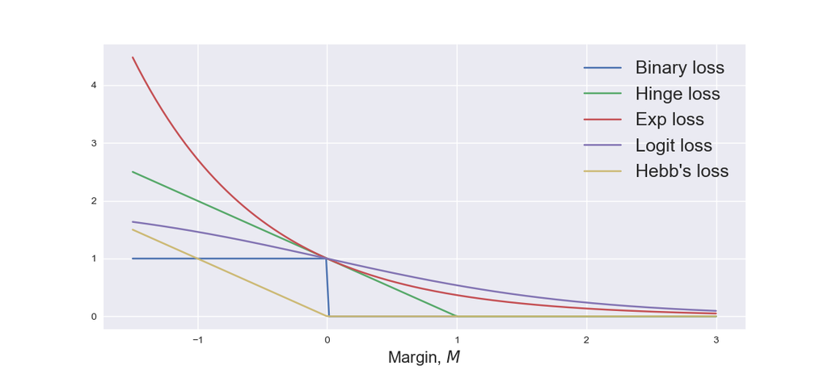

```python
%matplotlib notebook
import matplotlib.pyplot as plt
import seaborn as sns
sns.set()
import numpy as np

margin = np.linspace(-1.5, 3, 200)
svm_y = np.maximum(np.zeros_like(margin), 1 - margin)
bin_y = margin < 0
adaboost_y = np.exp(-margin)
logit_y = 2. / (1 + np.exp(margin))
hebbs_y = np.maximum(0, -margin)

plt.figure(figsize=(6, 5))
plt.plot(margin, bin_y, label="Binary loss")
plt.plot(margin, svm_y, label="Hinge loss")
plt.plot(margin, adaboost_y, label="Exp loss")
plt.plot(margin, logit_y, label="Logit loss")
plt.plot(margin, hebbs_y, label="Hebb's loss")
plt.legend(fontsize=18)
plt.xlabel("Margin, $M$", fontsize=16)
plt.show()
```

### Clustering

Dataset $x_i, \; i = 1,\dots, m$ and similarity measure $\rho(\cdot, \cdot)$

- Assign same labels $a_i$ to close samples, split dataset to homogeneous groups
- Loss functions:
- Average inner cluster distance $$ ID = \frac{\sum_{i < j}[a_i = a_j] \rho(x_i, x_j)}{\sum_{i < j} [a_i = a_j]} \to \min $$
- Average external cluster disctance $$ ED = \frac{\sum_{i < j}[a_i \not= a_j] \rho(x_i, x_j)}{\sum_{i < j} [a_i \not= a_j]} \to \max $$
- Probabilistic interpretation as GMM

### Ranking

Dataset $(q_i, d_i) \in X, y_i \in Y$, where $q_i$ is a query, $d_i$ is a document and $y_i$ is a relevance

- $a: X \to Y$ such that $(q, d) \succ (q, d') \equiv a(q, d) > a(q, d')$
- Loss function: $$ [a(x_j) - a(x_i) < 0], \quad i \prec j $$ or its upper bound again!
- Margin $M = a(x_j) - a(x_i)$
- Complete analogy with classification in upper bounds for binary loss function
- Quality criteria are specific: NDCG, pFound, precision, etc

## Optimization methods categories

- Zero order
- First order
- Second order
- Stochastic vs. deterministic
- Unconstrained vs. constrained
- Local vs. global

### Convexity phenomenon

- Local is global
- Neccessary conditions are sufficient

### Descent methods

$$ x_{k+1} = x_k + \alpha d_k $$

- How to choose $x_0$?
- How to choose $\alpha$?
- How to find $d_k$?

### Where do we descent?

- Decreasing condition $$ f(x_{k+1}) < f(x_k) $$ leads to classical methods
- Rejection of this condition leads to accelerated methods — advanced topics

## First order methods

- Require gradient
- Weak assumptions
- Typically sublinear or linear convergence
- Appropriate for large and huge scale problems

### Gradient descent

- Direction $$ d_k = -f'(x_k) $$
- Step size
  - Constant
  - Fix decreasing sequence
  - The steepest descent
  - Adaptive, like Armijo rule $ f(x_{k+1}) \leq f(x_k) - \beta_1 \alpha_k \langle f'(x_k), d_k \rangle $

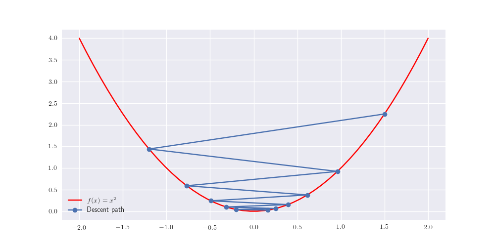

```python
%matplotlib notebook
import matplotlib.pyplot as plt
import seaborn as sns
sns.set()
import numpy as np
import ipywidgets as ipywidg

def gd(f, gradf, x0, step, eps=1e-6, maxiter=10):
    x = x0
    x_hist = [x]
    n_iter = 0
    while abs(gradf(x)) > eps and n_iter < maxiter:
        x = x - step * gradf(x)
        x_hist.append(x)
        n_iter += 1
    return x, x_hist

f = lambda x: x**2
gradf = lambda x: 2 * x

fig = plt.figure()
ax = fig.add_subplot(1, 1, 1)
plt.rc("text", usetex=True)

def update(x0, step):
    _, x_hist = gd(f, gradf, x0, step)
    x = np.linspace(-2, 2)
    ax.clear()
    ax.plot(x, f(x), color="r", label="$f(x) = x^2$")
    ax.plot(x_hist, [f(x) for x in x_hist], marker="o", label="Descent path")
    plt.legend()
    fig.canvas.draw()

step_slider = ipywidg.FloatSlider(value=0.8, min=0, max=1.2, step=0.1, description="Step")
x0_slider = ipywidg.FloatSlider(value=1.5, min=-2, max=2, step=0.1, description="Initial point")
_ = ipywidg.interact(update, x0=x0_slider, step=step_slider)
```

### One more interpretation

Consider ODE: $$ \frac{dx}{dt} = -f'(x(t)) $$ and discretize it on the regular grid with step size $\alpha$: $$ \frac{x_{k+1} - x_k}{\alpha} = -f'(x_k), $$ where $x_k \equiv x(t_k)$ and $\alpha = t_{k+1} - t_k$ - grid step.

Deduce the equation for $x_{k+1}$ $$ x_{k+1} = x_k - \alpha f'(x_k), $$ which is exactly the same as gradient descent update.

Such scheme is called explicit or forward Euler scheme.

**Q:** what scheme is called implicit or backward?

### Some facts

- GD converges at least to stationary point
- For strong convex functions convergence by function is linear
- For Lipschitz gradient function convergence is at least sublinear as $O\left(\frac{1}{k}\right)$
- Zig-zag trajectory for function with poor conditioned hessian and bad initial point

## Pro & Contra

Pro

- easy implementation
- convergence at least to stationary point
- a lot of variants

Contra

- linear convergence
- very strong dependence on condition number of $f''(x)$, good choice of initial point can help
- not optimal for covex functions with Lipschitz gradient and strong convex functions (see [Nesterov acceleration](https://blogs.princeton.edu/imabandit/2013/04/01/acceleratedgradientdescent/) to get $O\left(\frac{1}{k^2}\right)$ convergence rate)

### Stochastic extensions

- These methods explore structure of loss for all machine learning problems
- Loss is a sum of losses for every sample!

#### Stochastic gradient descent

- Initialize $w$ and compute total loss for it
- Pick random sample
- Compute loss for this sample
- Compute gradient only for picked sample
- Update $w$ only for computed gradient
- Update total loss

#### SAG

- Initialize $w$ and compute total loss for it
- Compute gradient for every sample
- Pick random sample
- Compute loss for this sample
- Compute gradient only for picked sample
- Update average gradient
- Update $w$ with average gradient
- Update total loss

#### AdaGrad

- From Neural Network training
- Scale step size proportionally to speed of changes gradient norm w.r.t every $x_k$
  - $ r = r + f'(x_k) \odot f'(x_k)$
  - $x_{k+1} = x_{k} - \frac{\varepsilon}{\sqrt{\delta + r}}\tilde{f}'(x_k) $ here all operations are element-wise
- Further improvements are about tuning step size to decrease gradient variance and improve stability

### Initialization approaches

- Zero
- Random (uniformly or gaussian) near 0
- Learning on small subset
- Multistart

#### How to pick random sample?

- Uniformly
- Higher error, larger probability to pick
- Ignore samples with high margin $M > m_+$
- Ignore samples that are outliers $M < m_- $

### Pro & Contra

**Pro**

- Simple idea
- Good convergence even if not all samples were picked at least once
- Online setting

**Contra**

- A lot of heuristics

## Second order methods

- Require hessian
- Faster converge
- More costly
- Only for small-medium scale problems

### Newton method

- Direction $$ d_k = -(f''(x_k))^{-1}f'(x_k) $$
- Step size strategies are the same as for GD
- Related to root finding from the neccessary optimality condition $$ f'(x_*) = 0 $$

### Some facts

- Initialization significantly affects convergence
- Linear convergence + quadratic convergence $$ \|x_{k+1}−x_∗\|_2 \leq C\|x_k−x_∗\|^2_2 $$
- Good method for functions that can be locally approximated by quadratic function

### Pro & Contra

**Pro**

- Quadratic convergence in the solution neighborhood
- Parameters have not affect convergence significantly

**Contra**

- Hessian storage is required for every iteration: $O(n^2)$ memory
- Linear system solving is required: $O(n^3)$ operations
- Hessian may be singular
- Hessian may be indefinite $\to$ direction $d_k$ is not descent direction

### Comparison with GD

| Method | Convergence rate | Complexity | Assumptions about $f(x)$ |
| --- | --- | --- | --- |
| GD | Global linear | $O(n) + $ step size search | Differentiable; Lipschitz gradient |
| Newton | Local quadratic | $O(n^3) + $ step size search | Twice differentiable; Lipschitz positive definite hessian |

### Some examples

$$ f(x) = x^4 $$

```python
%%capture
%matplotlib inline
import matplotlib.pyplot as plt
import matplotlib.animation
import seaborn as sns
sns.set()
plt.rcParams["animation.html"] = "html5"
from pylab import rcParams
rcParams['figure.figsize'] = 13, 7
import numpy as np

x_min, x_max = -1, 1
y_min, y_max = 0, 2
N_iter = 20
x_0 = 1

fig, ax = plt.subplots()
xdata = np.linspace(x_min,x_max)
ydata = xdata**4
plt.plot(xdata, ydata)
plt.title('NEWTON! $y = x^4$')
plt.xlabel('$x$')
plt.ylabel('$f(x) = x^4$')
line, = ax.plot([], [], marker='o', linestyle='-', color='r', label='Newton', lw=2)
plt.legend()
# ax.grid()
xdata, ydata = [x_0], [x_0**4]

def data_gen(t=0):
    cnt = 0
    x = x_0
    while cnt < N_iter:
        cnt += 1
        x = 2/3*x
        yield x


def init():
    ax.set_ylim(y_min, y_max)
    ax.set_xlim(x_min, x_max)
    line.set_data(xdata, ydata)
    return line,

def run(data):
    # update the data
    x = data
    y = x**4
    xdata.append(x)
    ydata.append(y)
    line.set_data(xdata, ydata)
    return line,

ani = matplotlib.animation.FuncAnimation(fig, run, data_gen, blit=False, interval=1000,
                              repeat=True, init_func=init)
```

```python
ani
```

[video not shown]

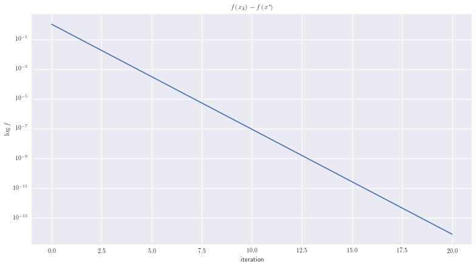

```python
from pylab import rcParams
rcParams['figure.figsize'] = 13, 7
plt.semilogy(ydata)
plt.title('$f(x_k) - f(x^*)$')
plt.xlabel('iteration')
plt.ylabel('$\log f$')
plt.show()
```

$$ f(x) = \sqrt{1 + x^2} $$

```python
%%capture
%matplotlib inline
import matplotlib.pyplot as plt
import seaborn as sns
sns.set()
import matplotlib.animation
plt.rcParams["animation.html"] = "html5"
from pylab import rcParams
rcParams['figure.figsize'] = 13, 7
import numpy as np

x_min, x_max = -3, 3
y_min, y_max = 1, 3
N_iter = 15
x_0 = 0.9



fig, ax = plt.subplots()
xdata = np.linspace(x_min,x_max)
ydata = np.sqrt(1 + xdata**2)
plt.plot(xdata, ydata)
plt.title('NEW $y = \sqrt{1 + x^2}$ ')
plt.xlabel('$x$')
plt.ylabel('$f(x)$')
line, = ax.plot([], [], marker='o', linestyle='-', color='r', label='Newton', lw=2)
plt.legend()
# ax.grid()
xdata, ydata = [x_0], [np.sqrt(1 + x_0**2)]

def data_gen(t=0):
    cnt = 0
    x = x_0
    while cnt < N_iter:
        cnt += 1
        x = -x**3
        yield x


def init():
    ax.set_ylim(y_min, y_max)
    ax.set_xlim(x_min, x_max)
    line.set_data(xdata, ydata)
    return line,

def run(data):
    # update the data
    x = data
    y = np.sqrt(1 + x**2)
    xdata.append(x)
    ydata.append(y)
    line.set_data(xdata, ydata)
    return line,

ani = matplotlib.animation.FuncAnimation(fig, run, data_gen, blit=False, interval=1000,
                              repeat=True, init_func=init)
```

```python
ani
```

[video not shown]

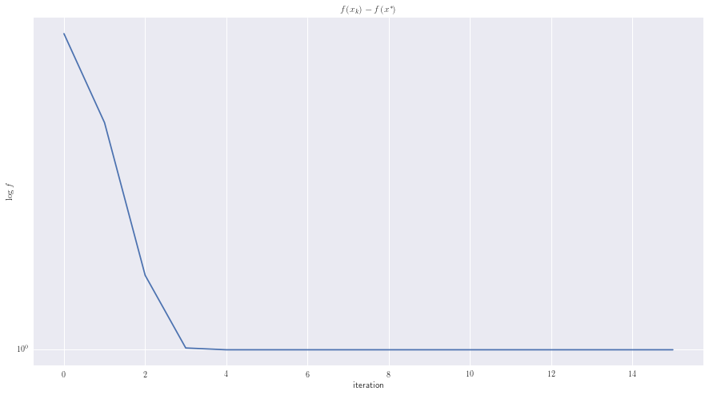

```python
from pylab import rcParams
rcParams['figure.figsize'] = 15, 8
plt.semilogy(ydata)
plt.title('$f(x_k) - f(x^*)$')
plt.xlabel('iteration')
plt.ylabel('$\log f$')
plt.show()
```

## How to combine pros of GD and Newton methods?

- Reduce complexity and assumptions for Newton methods
- But try to achieve quadratic convergence

## Quasi-Newton methods

- Main idea: approximate hessian with simple matrix or even with combinations of gradients!
- Fast matrix by vector product
- No storage issues
- May loose quadratic convergence

### Approximate expansion

$$ f_q(x) \approx f(y) + \langle f'(y), x - y \rangle + \frac{1}{2} (x-y)^{\top}{\color{red}{B(y)}}(x-y), $$ which leads to the following update $$ x_{k+1} = x_k - \alpha B^{-1}_k f'(x_k) = x_k - \alpha H_k f'(x_k) $$

### How define $B_{k+1}$ correctly?

At $x_{k+1}$ we have: $$ f_q(h) \approx f(x_{k+1}) + \langle f'(x_{k+1}), h \rangle + \frac{1}{2}h^{\top}B_{k+1}h $$

Constraint for $f_q(h)$ $$ f_q'(-\alpha_k h_k) = f'(x_k) \qquad f'_q(0) = f'(x_{k+1}), $$ where the first equation gives $$ f'(x_{k+1}) - \alpha_k B_{k+1}h_k = f'(x_k), $$ and the second one is automatically satisfied.

### Secant equation

$$ B_{k+1}s_k = y_k, $$ where $s_k = x_{k+1} - x_k$ and $y_k = f'(x_{k+1}) - f'(x_k)$.

This equation is correct only if $s^{\top}_k y_k > 0$. Why?

### Uniqueness of $B_{k+1}$

\begin{equation} \begin{split} & \min_B \| B_k - B \| \\ \text{s.t. } & B = B^{\top}\\ & Bs_k = y_k \end{split} \end{equation}

### DFP (Davidon-Fletcher-Powell)

$$ B_{k+1} = (I - \rho_k y_k s^{\top}_k)B_k(I - \rho_k s_ky^{\top}_k) + \rho_k y_k y^{\top}_k, $$ where $\rho_k = \dfrac{1}{y^{\top}_k s_k}$,

or with Sherman-Morrison-Woodbury $$ B^{-1}_{k+1} = H_{k+1} = H_k - \dfrac{H_ky_k y_k^{\top}H_k}{y^{\top}_kH_ky_k} + \dfrac{s_ks^{\top}_k}{y^{\top}_ks_k} $$

### YES!

[figure not shown]

### BFGS method

\begin{equation} \begin{split} & \min_H \| H_k - H \| \\ \text{s.t. } & H = H^{\top}\\ & Hy_k = s_k \end{split} \end{equation}

$$ H_{k+1} = (I - \rho_k s_ky^{\top}_k)H_k(I - \rho_k y_k s^{\top}_k) + \rho_k s_k s^{\top}_k, $$ where $\rho_k = \dfrac{1}{y^{\top}_k s_k}$

### Pro & Contra

Pro:

1. Inverse hessian computed analytically
2. Complexity $O(n^2) + ...$
3. Self-correction property
4. Suprlinear convergence

Contra:

1. Heuristics in initialization $B_0$ and $H_0$
2. Convergence theory is not complete
3. Not any step size strategy leads to curvture condition $y^{\top}_ks_k > 0$
4. Still have storage issues

### L-BFGS

- Do not store hessian
- But store limited number of its building blocks $y_k, s_k$ in deque
- After each iteration pop last pair and push new one
- Fast matrix by vector product and linear space complexity!
- Initialization $H_0$ as diagonal or even identity

## Constrained optimization

### Problem statement

\begin{equation} \begin{split} & \min_{x \in S} f(x)\\ \text{s.t. } & g_i(x) = 0, \; i = 1,\ldots,m\\ & h_j(x) \leq 0, \; j = 1,\ldots,p \end{split} \end{equation} where $S \subseteq \mathbb{R}^n$, $f: S \rightarrow \mathbb{R}$, $g_i: S \rightarrow \mathbb{R}, \; i=1,\ldots,p$ and the same for $h_j$

Functions are at least continuous.

### Lagrangian and KKT optimality conditions

\begin{equation*} L(x, \lambda, \mu) = f(x) + \sum\limits_{i=1}^m\lambda_i g_i(x) + \sum\limits_{j=1}^p \mu_j h_j(x) \end{equation*}

- Let $x^*$ be the solution if the problem and functions $f, h_j, g_i$ are differentiable. Then there exist $\mu^*$ и $\lambda^*$ such that:
  - $g_i(x^*) = 0$
  - $h_j(x^*) \leq 0$
  - $\mu^*_j \geq 0$
  - $\mu^*_jh_j(x^*) = 0$
  - $\nabla_x L(x^*, \lambda^*, \mu^*) = 0$
- If the problem is convex, this conditions are also sufficient.

### How to use KKT?

- Check the candidate points on optimality
- Direct solving in the convex case to find the solution
- Relax complementary slackness and get interrior point methods

### Duality theory

- Construct lower bound for the objective function
- **Maximize** this lower bound w.r.t. dual variables
- Hope that bound is tight

### Lagrangian again and dual function

\begin{equation*} L(x, \lambda, \mu) = f(x) + \sum\limits_{i=1}^m\lambda_i g_i(x) + \sum\limits_{j=1}^p \mu_j h_j(x) \leq f(x), \quad \mu_j \geq 0 \end{equation*}

- $\lambda$ and $\mu$ are dual variables
- Dual function $$ g(\lambda, \mu) = \min_{x} L(x, \lambda, \mu) $$
- Dual function is always concave (why?)

### Dual problem

- Dual problem \begin{align*} & \max_{\mu, \lambda} g(\lambda, \mu) \\ \text{s.t. } & \lambda \geq 0 \end{align*}
- Dual problem is always convex!
- Lower bound can be tight!

### Duality gap

- By construction $p^* \geq g(\lambda, \mu)$, therefore $f_0(x) - p^* \leq f_0(x) - g(\lambda, \mu) = \varepsilon$.
- $f_0(x) - g(\lambda, \mu)$ is called *duality gap* and is upper bound for difference between current approximation and optimal function value
- Use cases
  - stopping criterion in iteration process
  - theoretical estimation of the iterative provess convergnence
  - check optimality of the current point

### Slater condition

- Weak duality: $g(\lambda^*, \mu^*) < p^*$ — always by definition!
- Strong duality: $g(\lambda^*, \mu^*) = p^*$
- If the problem is convex and there exists $x$ inside the feasible region, i.e. inequality constraints are strictly feasible, then strong duality exists.

### Interior point methods

\begin{equation*} \begin{split} & \min_{x \in \mathbb{R}^n} f_0(x)\\ \text{s.t. } & f_i (x) \leq 0 \qquad i=1,\ldots,m\\ & Ax = b, \end{split} \end{equation*} where $f_i$ are convex and twice continuously differentiable, $A \in \mathbb{R}^{p \times n}$ and $\mathrm{rank} \; A = p < n$.

Assume that the problem is strictly feasible, i.e. Slater conditions are satisfied.

### Equality constraint convex optimization

- Write KKT
- Construct system for Newton method
- See that the equlity constrained convex optimization is very similar to the unconstrained case

### General convex optimization problem

- What is the main difference?
- How to deal with it?

### Main idea of interior point methods

- Reduce the problem with **inequality** contraints to sequence of **equality** constrained optimization problems
- Apply optimizaton methods for equality constrained optimization problems

\begin{equation*} \begin{split} & \min f_0(x) + \sum_{i=1}^m I_-(f_i(x))\\ \text{s.t. } & Ax = b, \end{split} \end{equation*} where $I_-$ — indicator function $$ I_-(u) = \begin{cases} 0, & u \leq 0\\ \infty, & u > 0 \end{cases} $$

**Issue.** Now the objective function is not differentiable!

### Logarithmic barrier

**Idea.** Approximate indicator function $I_-(u)$ with the function $$ \hat{I}_-(u) = -t\log(-u), $$ where $t > 0$ is a parameter.

- Functions $I_-(u)$ and $\hat{I}_-(u)$ are convex and nondecreasing
- But $\hat{I}_-(u)$ is **differentiable** and approximate $I_-(u)$ while $t \to 0$

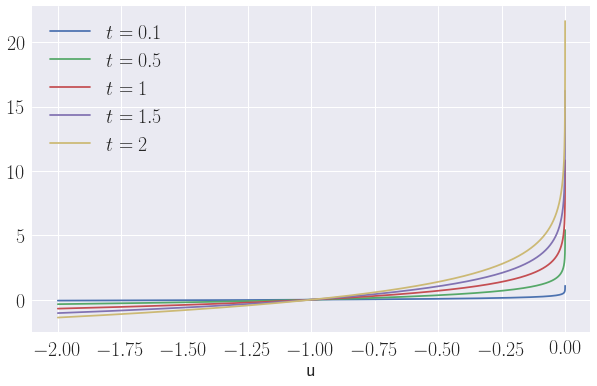

```python
%matplotlib inline
import matplotlib.pyplot as plt
import seaborn as sns
sns.set()
import numpy as np

x = np.linspace(-2, 0, 100000, endpoint=False)
plt.figure(figsize=(10, 6))
for t in [0.1, 0.5, 1, 1.5, 2]:
    plt.plot(x, -t * np.log(-x), label=r"$t = " + str(t) + "$")
plt.legend(fontsize=20)
plt.xticks(fontsize=20)
plt.yticks(fontsize=20)
plt.xlabel("u", fontsize=20)
plt.show()
```

### Logarithmic subproblems

\begin{equation*} \begin{split} & \min f_0(x) + \sum_{i=1}^m -t \log(-f_i(x))\\ \text{s.t. } & Ax = b \end{split} \end{equation*}

- The problem is again **convex**
- Function $$ \phi(x) = -\sum\limits_{i=1}^m \log(-f_i(x)) $$ is called *logarithmic barrier*.

**Exerсise**. Find gradient and hessian of $\phi(x)$

### Central path and KKT interpretation

- For every $t > 0$ logarithmic subproblems have unique solution $x^*(t)$.

**Definition.** Sequence $x^*(t)$ for $t > 0$ composes *central path*.

- KKT interpretation and convergence basics $$ -\lambda_i f_i(x) = 0 \Rightarrow - \lambda_i f_i(x) = t \quad i = 1,\ldots, m $$
- Dulaity gap can be estimated as $$ f_0(x^*(t)) - p^* \leq mt $$

## Summary

- Optimization problem statements
- First order methods
- Second order methods
- Stochastic methods
- Constrained optimization
- KKT and duality
- Interior point methods